```python
#Para generar html
%%shell
jupyter nbconvert --to html /content/Segmentaciondeclientes.ipynb
```

```
[NbConvertApp] Converting notebook /content/Segmentaciondeclientes.ipynb to html
[NbConvertApp] Writing 1273219 bytes to /content/Segmentaciondeclientes.html
```

# Trabajo 2: Segmentacion para el curso de Técnicas en Aprendizaje Estadístico

## Integrantes:

- Julián Alejandro Usuga Ortiz
- Santiago Campos Giraldo
- Juan José Hurtado Álvarez
- Santiago Poveda Grajales
- Diego de Oliveira Hitzges

## Introducción

Para el presente trabajo que se desarrollará, se hará una segmentación de clientes corporativos de una empresa tanto para las variables de comportamiento, como las variables de estados financieros. Para el primer tipo de variables, primero se usarán los histogramas de frecuencia para así observar la distribución de los datos del "valor medio" y "cantidad de transacciones" y hacer una primera segmentación según salidas y entradas.

Por otro lado principalmente buscando la identificación de patrones comunes entre clientes, evaluación y visualización del comportamiento general de las variables por medio de la matriz de correlación de Pearson y así tratar evaluar las variables que más nos podrían aportar al modelo; para posteriormente proceder a la clasificación mediante el método de K-means, algoritmo que se ajusta muy bien a este problema de aprendizaje no supervisado y de agrupación por medio de características en común.

## Análisis de los datos

Importamos las librerías necesarias para realizar el análisis de los datos y la clusterización:

- Random --> Generación valores aleatorios
- Pandas --> Manipulación y análisis de datos
- Numpy --> Cálculos numéricos y estructuras de datos
- Matplotlib --> Creación de gráficos
- Seaborn --> Visualización de datos

```python
import random
import pandas as pd
import numpy as np
import matplotlib.pyplot as plt
import seaborn as sb
from IPython.display import display



#Mostrar todas las columnas
pd.options.display.max_columns = None
```

Leemos los datos y mostramos los primeros 5, las variables están explicadas de la siguiente manera:  
**Variables de comportamiento de los clientes en canales y productos:**  
en_vm_canalX: Valor promedio del ticket de entrada por el canal X, X = 1-10, otros  
sal_vm_canalX: Valor promedio del ticket de salida por el canal X, X = 2, 5, 8, otros  
en_tx_canalX: Cantidad de transacciones de entrada por el canal X, X = 1-10, otros  
sal_tx_canalX: Cantidad de transacciones de salida por el canal X, X = 2, 5, 8, otros  
**Variables de estados financieros y características de los clientes:**  
impo_cv: importaciones/compras categorizadas  
expo_vt: exportaciones/ventas  
cxp: cuentas por pagar categorizada con seis niveles  
cxc: cuentas por cobrar categorizada con seis niveles  
totalinventory: valor de inventarios categorizada con seis niveles  
pagos_pj: pagos hechos a personas jurídicas/pagos totales  
pagos_pn: pagos hechos a personas naturales/pagos totales  
tiene_ventas_fisicas: la empresa tiene puntos de venta físicos (1:Si, 0:No)  
tiene_ventas_electronicas: la empresa tiene ventas electrónicas (1:Si, 0:No)  
recaudos_pj: recaudos provenientes de personas jurídicas/recaudos totales  
recaudos_pn: recaudos provenientes de personas naturales/recaudos totales  
rotacion_inventarios: rotación de inventarios en días categorizada con seis niveles  
rotacion_cxc: rotación de cuentas por pagar en días categorizada con seis niveles  
rotacion_cxp: rotación de cuentas por cobrar en días categorizada con seis niveles  
ciclo_negocio: ciclo de negocio en días categorizada con seis niveles  
ciclo_financiero: ciclo financiero en días categorizada con seis niveles

```python
datos = pd.read_csv("base_trabajo_segmentacion.csv", sep=";") #<----
datos.head()
```

|  | nit | en_vm_canal1 | en_vm_canal2 | en_vm_canal3 | en_vm_canal4 | en_vm_canal5 | en_vm_canal6 | en_vm_canal7 | en_vm_canal8 | en_vm_canal9 | en_vm_canal10 | en_vm_otros | en_tx_canal1 | en_tx_canal2 | en_tx_canal3 | en_tx_canal4 | en_tx_canal5 | en_tx_canal6 | en_tx_canal7 | en_tx_canal8 | en_tx_canal9 | en_tx_canal10 | en_tx_otros | sal_vm_canal5 | sal_vm_canal2 | sal_vm_canal8 | sal_vm_otros | sal_tx_canal5 | sal_tx_canal2 | … |
| --- | --- | --- | --- | --- | --- | --- | --- | --- | --- | --- | --- | --- | --- | --- | --- | --- | --- | --- | --- | --- | --- | --- | --- | --- | --- | --- | --- | --- | --- | --- |
| 0 | C4936394968152386565 | 0.000000e+00 | 0.000000e+00 | 0.000000e+00 | 0.00 | 0.0 | 0.00 | 0.000000e+00 | 0.0 | 0.00 | 0.0 | 0.0 | 0.000000 | 0.000000 | 0.000000 | 0.000000 | 0.000000 | 0.0 | 0.00 | 0.0 | 0.0 | 0.0 | 0.0 | 0.0 | 0.000000e+00 | 0.0 | 0.0 | 0.000000 | 0.000000 | … |
| 1 | C-8615176103348111575 | 0.000000e+00 | 0.000000e+00 | 0.000000e+00 | 0.00 | 0.0 | 0.00 | 0.000000e+00 | 0.0 | 0.00 | 0.0 | 0.0 | 0.000000 | 0.000000 | 0.000000 | 0.000000 | 0.000000 | 0.0 | 0.00 | 0.0 | 0.0 | 0.0 | 0.0 | 0.0 | 0.000000e+00 | 0.0 | 0.0 | 0.000000 | 0.000000 | … |
| 2 | C2364605246729357060 | 2.509275e+08 | 5.416089e+07 | 5.122152e+06 | 41852510.17 | 413614314.7 | 1663236.40 | 2.106848e+09 | 0.0 | 0.00 | 0.0 | 0.0 | 24.416667 | 11.916667 | 3.333333 | 237.833333 | 2.545455 | 5.4 | 8.25 | 0.0 | 0.0 | 0.0 | 0.0 | 413614314.7 | 2.265361e+09 | 0.0 | 0.0 | 2.545455 | 613.083333 | … |
| 3 | C7393816976826597531 | 3.940236e+07 | 9.646900e+07 | 8.226710e+06 | 0.00 | 0.0 | 7072801.90 | 0.000000e+00 | 9000000.0 | 0.00 | 0.0 | 0.0 | 14.416667 | 13.833333 | 4.600000 | 0.000000 | 0.000000 | 2.8 | 0.00 | 1.0 | 0.0 | 0.0 | 0.0 | 0.0 | 6.055844e+07 | 0.0 | 0.0 | 0.000000 | 10.333333 | … |
| 4 | C872645851723947566 | 3.374323e+08 | 2.342179e+08 | 1.053441e+08 | 15755286.83 | 0.0 | 23671840.33 | 0.000000e+00 | 3600962.2 | 3727298.56 | 0.0 | 0.0 | 153.583333 | 42.250000 | 102.416667 | 49.333333 | 0.000000 | 18.0 | 0.00 | 2.2 | 4.0 | 0.0 | 0.0 | 0.0 | 0.000000e+00 | 0.0 | 622080714.3 | 0.000000 | 0.000000 | … |

```python
datos.shape
```

```
(2233, 47)
```

Por simplicidad, sumaremos el valor del ticket promedio de entrada de todos los canales y así obtendremos una nueva variable que representará la entrada total de los canales. De la misma manera procederemos con la cantidad de transacciones promedio. Todo este proceso se hará tanto para la entrada como para la salida.

```python
columns = ["en_vm_", "en_tx_", "sal_vm_", "sal_tx_"]
for c in columns:
    #columnas que empiezan en c
    col_list = list(datos.columns[pd.Series(datos.columns).str.startswith(c)])

    #Suma todas las columnas y las guarda en c + "total"
    datos[c + "total"] = datos[col_list].sum(axis=1)

    #Borro las columnas c y dejo c + "total"
    datos = datos.drop(col_list, axis=1)

datos.head()
```

|  | nit | impo_cv | expo_vt | cxp | cxc | totalinventory | pagos_pj | pagos_pn | tiene_ventas_fisicas | tiene_ventas_electronicas | recaudos_pj | recaudos_pn | rotacion_inventarios | rotacion_cxc | rotacion_cxp | ciclo_negocio | ciclo_financiero | en_vm_total | en_tx_total | sal_vm_total | sal_tx_total |
| --- | --- | --- | --- | --- | --- | --- | --- | --- | --- | --- | --- | --- | --- | --- | --- | --- | --- | --- | --- | --- | --- |
| 0 | C4936394968152386565 | 1 | 1 | 6 | 6 | 6 | 0.000 | 0.000 | 0 | 0 | 0.0 | 0.0 | 6 | 2 | 2 | 5 | 6 | 0.000000e+00 | 0.000000 | 0.000000e+00 | 0.000000 |
| 1 | C-8615176103348111575 | 1 | 1 | 2 | 6 | 2 | 1.000 | 0.000 | 0 | 0 | 0.0 | 0.0 | 1 | 3 | 1 | 3 | 4 | 0.000000e+00 | 0.000000 | 0.000000e+00 | 0.000000 |
| 2 | C2364605246729357060 | 1 | 1 | 3 | 1 | 2 | 0.456 | 0.544 | 1 | 0 | 0.0 | 0.0 | 2 | 1 | 2 | 2 | 1 | 2.874188e+09 | 293.695455 | 2.678976e+09 | 615.628788 |
| 3 | C7393816976826597531 | 2 | 2 | 1 | 1 | 1 | 0.615 | 0.385 | 1 | 0 | 0.0 | 0.0 | 5 | 2 | 3 | 5 | 5 | 1.601709e+08 | 36.650000 | 6.055844e+07 | 10.333333 |
| 4 | C872645851723947566 | 1 | 1 | 2 | 2 | 2 | 1.000 | 0.000 | 1 | 0 | 0.0 | 0.0 | 2 | 2 | 1 | 3 | 3 | 7.237497e+08 | 371.783333 | 6.220807e+08 | 53.416667 |

Analizamos los histogramas de las entradas y salidas totales de los canales.

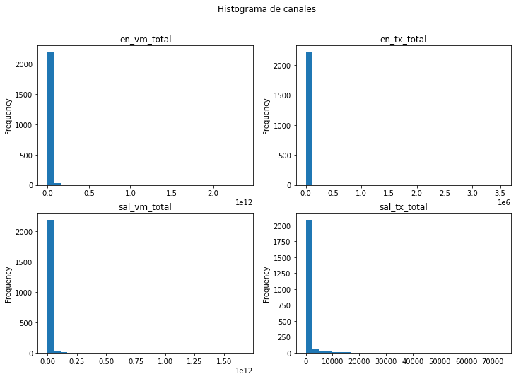

```python
cols = [['en_vm_total', 'en_tx_total'], ['sal_vm_total', 'sal_tx_total']]

fig, axes = plt.subplots(nrows=2, ncols=2,figsize=(12,8))
fig.suptitle("Histograma de canales")
for x in [0, 1]:
    for y in [0, 1]:
        datos[cols[x][y]].plot.hist(bins=30, ax=axes[x,y], title = cols[x][y])
```

Al ver que el histograma no dice mucho, se decide hacer una transformación logaritmica, ya que las variables son positivas, y después de eso analizar nuevamente los histogramas con las transformaciones ya aplicadas.

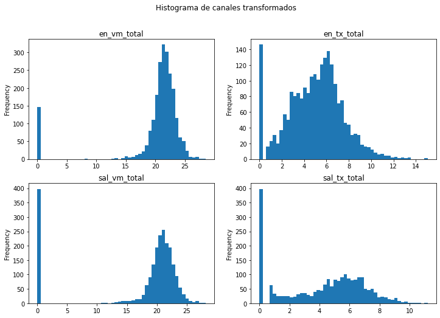

```python
#############################
def log_transformation(y):
    return np.log(y+1)
#############################


fig, axes = plt.subplots(nrows=2, ncols=2,figsize=(12,8))
fig.suptitle("Histograma de canales transformados")
for x in [0, 1]:
    for y in [0, 1]:
        t_log_datos = log_transformation(datos[cols[x][y]])
        t_log_datos.plot.hist(bins=50, ax=axes[x,y], title = cols[x][y])
```

Para mejorar el comportamiento de las distribuciones, normalizamos los canales y volvemos a analizar el histograma.

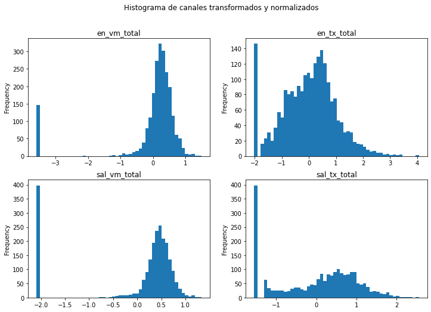

```python
fig, axes = plt.subplots(nrows=2, ncols=2,figsize=(12,8))
fig.suptitle("Histograma de canales transformados y normalizados")
for x in [0, 1]:
    for y in [0, 1]:
        t_log_datos = log_transformation(datos[cols[x][y]])
        mu = t_log_datos.mean()
        sd = t_log_datos.std()
        t_log_norm = (t_log_datos - mu)/sd
        datos[cols[x][y] + "_t"] = t_log_norm
        t_log_norm.plot.hist(bins=50, ax=axes[x,y], title = cols[x][y])
```

Primera segmentación de comportamiento de los clientes, según si sus entradas o salidas son menores que, medias o mayores que... en las variables Valor medio y Cantidad de transacciones

```python
# Para segmentar entre personas valor medio
en_vm_lower_q = datos.en_vm_total_t.quantile(0.4)
en_vm_upper_q = datos.en_vm_total_t.quantile(0.6)
sal_vm_lower_q = datos.sal_vm_total_t.quantile(0.4)
sal_vm_upper_q = datos.sal_vm_total_t.quantile(0.6)
# Para segmentar numero de transacciones
en_tx_lower_q = datos.en_tx_total_t.quantile(0.4)
en_tx_upper_q = datos.en_tx_total_t.quantile(0.6)
sal_tx_lower_q = datos.sal_tx_total_t.quantile(0.4)
sal_tx_upper_q = datos.sal_tx_total_t.quantile(0.6)

#Para segmentar personas por valor medio (entrada o salida)

# Columnas con poco valor medio de entrada y alto valor medio de salida
datos.loc[(datos.en_vm_total_t < en_vm_lower_q) & (datos.sal_vm_total_t > sal_vm_upper_q), "vm_segmentation"] = "mayor_salida"

# Columnas con alto valor medio de entrada y poco valor medio de salida
datos.loc[(datos.en_vm_total_t > en_vm_upper_q) & (datos.sal_vm_total_t < sal_vm_lower_q), "vm_segmentation"] = "mayor_entrada"


# Para segmentar personas por numero de transacciones

# Columnas con poco valor medio de entrada y alto valor medio de salida
datos.loc[(datos.en_tx_total_t < en_tx_lower_q) & (datos.sal_tx_total_t > sal_tx_upper_q), "tx_segmentation"] = "mayor_salida"

# Columnas con alto valor medio de entrada y poco valor medio de salida
datos.loc[(datos.en_tx_total_t > en_tx_upper_q) & (datos.sal_tx_total_t < sal_tx_lower_q), "tx_segmentation"] = "mayor_entrada"


datos[["nit", "vm_segmentation", "tx_segmentation"]] = datos[["nit", "vm_segmentation", "tx_segmentation"]].fillna("normal")

#Mostrar los datos
datos[["nit", "vm_segmentation", "tx_segmentation"]][(datos.vm_segmentation != "normal") | (datos.tx_segmentation != "normal" )]
```

|  | nit | vm_segmentation | tx_segmentation |
| --- | --- | --- | --- |
| 4 | C872645851723947566 | normal | mayor_entrada |
| 5 | C-3870380727390720970 | mayor_salida | normal |
| 8 | C6428084652960048574 | normal | mayor_entrada |
| 9 | C-6937758062773673148 | normal | mayor_salida |
| 10 | C-6938443690430410016 | normal | mayor_entrada |
| ... | ... | ... | ... |
| 2170 | C-2112857680657541582 | normal | mayor_salida |
| 2174 | C7237847119346234982 | normal | mayor_salida |
| 2182 | C7242468423468657880 | normal | mayor_entrada |
| 2185 | C1631383687134926094 | mayor_entrada | normal |
| 2201 | C2229802797370305389 | normal | mayor_entrada |

433 rows × 3 columns

Con esta segmentación fuimos capaces de clasificar a los clientes de acuerdo al valor medio de sus transacciones en las categorías: - valor medio en transacciones (salida/entrada): - mayor_entrada: Si el cliente se destaca frente al comportamiento de la mayoría teniendo mayor entrada en sus transacciones. - mayor_salida: Si el cliente se destaca frente al comportamiento de la mayoría teniendo mayor salida en sus transacciones. - normal: El cliente no parece tener una preferencia, hay un comportamiento normal de acuerdo al resto de los clientes. - número de transacciones (salida/entrada): - mayor_entrada: Si el cliente se destaca frente al comportamiento de la mayoría teniendo un volumen de transacciones de entradas mucho mayor al de salida. - mayor_salida: Si el cliente se destaca frente al comportamiento de la mayoría teniendo un volumen de transacciones de salida mucho mayor al de entrada. - normal: El cliente no parece tener una preferencia, hay un comportamiento normal de acuerdo al resto de los clientes.

# Clustering

Para realizar un buen clustering, analizaremos la correlación de variables en una matriz de correlación, según lo observado obtendremos las características más influyentes y las cuales nos harán tener un mejor performance.

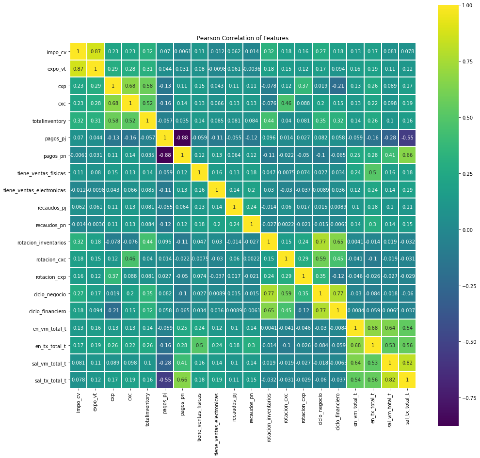

```python
datos_reduced = datos.drop(["nit","en_vm_total", "en_tx_total", "sal_vm_total", "sal_tx_total", "vm_segmentation", "tx_segmentation"], axis=1) #<---

colormap = plt.cm.viridis
plt.figure(figsize=(16,16))
plt.title('Pearson Correlation of Features')
sb.heatmap(datos_reduced.astype(float).corr(),
           vmax=1.0,
           cmap=colormap,
           annot=True,
           linewidths=1.0,
           linecolor='white',
           square=True)
```

En esta matriz podemos observar que hay variables muy correlacionadas entre sí, seleccionaremos las características más influyentes. Inicialmente observaremos las variables más influyentes que describen el estado financiero de los clientes. Analizaremos estos datos con un pairplot.

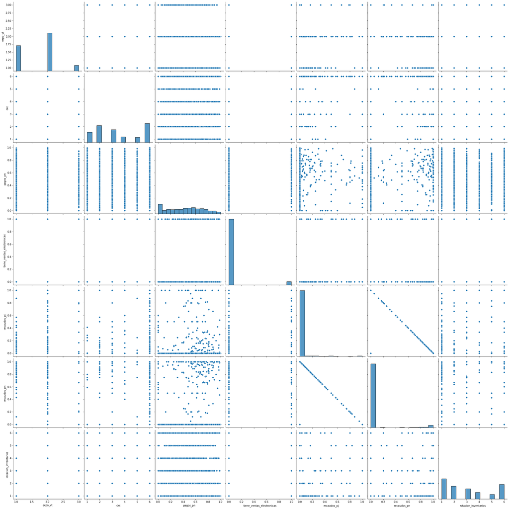

```python
datos_estado_financiero = datos[["expo_vt","cxc","pagos_pn","tiene_ventas_electronicas","recaudos_pj","recaudos_pn","rotacion_inventarios",]]

sb.pairplot(datos_estado_financiero,size=4,kind='scatter')
```

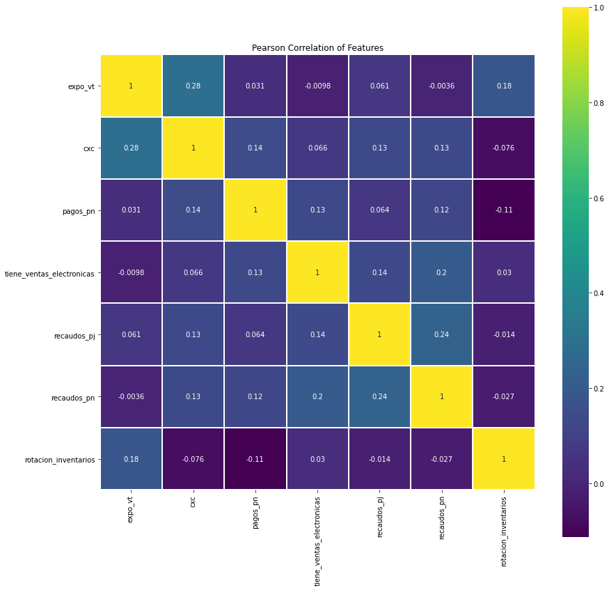

```python
colormap = plt.cm.viridis
plt.figure(figsize=(14,14))
plt.title('Pearson Correlation of Features')
sb.heatmap(datos_estado_financiero.astype(float).corr(),
           vmax=1.0,
           cmap=colormap,
           annot=True,
           linewidths=1.0,
           linecolor='white',
           square=True)
```

Al realizar una matriz de confusión de las características más influyentes que describen el estado financiero, vemos que ya la correlación entre sí es baja y cada variable aportará información.

De la primera matriz, también seleccionamos las características más influyentes que describen el comportamiento y los analizaremos con un pairplot nuevamente.

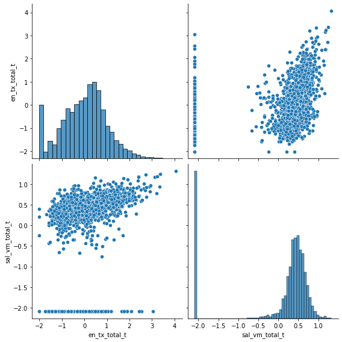

```python
datos_comportamiento = datos[["en_tx_total_t","sal_vm_total_t"]]

sb.pairplot(datos_comportamiento,size=4,kind='scatter')
```

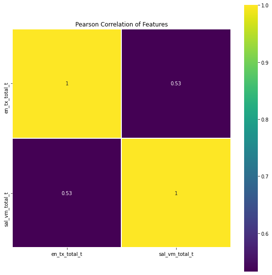

```python
colormap = plt.cm.viridis
plt.figure(figsize=(10,10))
plt.title('Pearson Correlation of Features')
sb.heatmap(datos_comportamiento.astype(float).corr(),
           vmax=1.0,
           cmap=colormap,
           annot=True,
           linewidths=1.0,
           linecolor='white',
           square=True)
```

Vemos que las características seleccionadas aportarán información y son las menos correlacionadas del comportamiento.

## Segmentación de los clientes con el algoritmo k-means

Elegimos las características más influyentes y para manipularlas de mejor manera, las convertiremos en un array de numpy, luego todo lo volveremos una matriz llamada X.

```python
#choose most important columns of the database and transform them into a numpy.array
nit = [entry for entry in datos["nit"]]

#variables of financial status
"expo_vt","cxc","pagos_pn","tiene_ventas_electronicas","recaudos_pj","recaudos_pn","rotacion_inventarios"
expo_vt = [entry for entry in datos["expo_vt"]]
cxc = [entry for entry in datos["cxc"]]
pagos_pn = [entry for entry in datos["pagos_pn"]]
tiene_ventas_electronicas = [entry for entry in datos["tiene_ventas_electronicas"]]
recaudos_pj = [entry for entry in datos["recaudos_pj"]]
recaudos_pn = [entry for entry in datos["recaudos_pn"]]
rotacion_inventarios = [entry for entry in datos["rotacion_inventarios"]]

#variables of behaviour
"en_tx_total_t","sal_vm_total_t"
en_tx_total_t = [entry for entry in datos["en_tx_total_t"]]
sal_vm_total_t = [entry for entry in datos["sal_vm_total_t"]]
```

```python
#turn data into matrix X
X = np.vstack((nit,expo_vt,cxc,pagos_pn,tiene_ventas_electronicas,recaudos_pj,recaudos_pn,rotacion_inventarios,en_tx_total_t,sal_vm_total_t))
X = X.T
list_of_clients = []
```

Para guardar la información de cada cliente, crearemos la clase Clients, que tendrá los siguientes atributos:

- nit: para identificar el cliente
- data: datos
- centroid: centro de cluster al que está asignado
- distance: distancia al centroide
- cluster: cluster al que pertenece
- members: si este cliente es centroide, se salvan todos los miembros.

```python
#create class of Clients to save information of every client
class Clients:

  #nit is to identify client, data is their information
	#to which cluster a client belongs is determined by the centroid of that cluster that it is assigned to
	#use also "cluster" and "members" to save for each centroid which are the assigned points to it
  def __init__ (self,nit,data):
    self.nit = nit
    self.data = data
    self.centroid = None
    self.distance = 99999999999999
    self.cluster = np.empty((0,np.shape(X)[1]-1))
    self.members = []
```

```python
#set seed for reproducability of results
np.random.seed(10)
```

Normalizamos los datos.

```python
#normalize the data
np.random.shuffle(X)
X_norm = np.copy(X)
X_data = X_norm[:,1:].astype(np.float)
x_mean = np.mean(X_data, axis=0).reshape(1,X_data.shape[1])
x_std = np.std(X_data, axis=0).reshape(1,X_data.shape[1])
X_norm[:,1:] = (X_data - x_mean) / x_std
```

Creamos una lista de clientes y los dividimos en k clusters, inicializamos los centroides eligiendolos aleatoriamente de la lista de los clientes, para cada cluster asignamos como nuevo centroide el cliente que esté más cerca a su punto central matemático. Después asignamos cada cliente otra vez al centroide más cercano, esto lo repetimos hasta que tengamos convergencia o alcancemos el limite de iteraciones predefinidas.

```python
#divide clients into k clusters
def k_means(k,epochs):

	#create list of clients, where every client is an instance form the former created class
  list_of_clients.clear()
  for i in range(len(X_norm)):
    nit = X_norm[i][0]
    data = X_norm[i][1:].astype(np.float)
    list_of_clients.append(Clients(nit,data))

	#initialize centroids by choosing them uniformly at random from the list of all clients
  random.seed(5)
  centroids = random.sample(list_of_clients,k)

	#start to iterate
  for e in range(epochs):

		#assign closest centroid to each client by using a double list search
    for client in list_of_clients:

      for centroid in centroids:
				#calculate distance to centroid
        dist = np.linalg.norm(client.data - centroid.data)
				#choose centroid with smallest distance
        if dist < client.distance:
          client.centroid = centroid
          client.distance = dist

			#save also for every centroid all the clients that are assigned to, so later one does not have to search the entire list of clients for that information
      client.centroid.cluster = np.vstack((client.centroid.cluster,client.data))
      client.centroid.members.append(client)

		#determine new centroids of each cluster by calculating their central point and choosing client that lies closest to it
    new_centroids = []
    for centroid in centroids:
			#search over all clients that belong to cluster
      cluster = centroid.cluster
			#calculate their central point by taking arithmetic mean
      center = np.mean(cluster, axis=0)

			#assign closest client to central point as new centroid of that cluster
      dist_to_center = 99999999999
			#iterative search over all clients belonging to cluster
      for client in centroid.members:
				#calculate distance to central point
        dist = np.linalg.norm(center - client.data)
				#if distance is smaller then of the currently assigned centroid, reassign this client as the centroid
        if dist < dist_to_center:
          new_centroid = client
          dist_to_center = dist

			#recalculate distance to new centroid for all clients in its cluster
      for client in centroid.members:
        client.centroid = new_centroid
        client.distance = np.linalg.norm(client.data - new_centroid.data)

			#reset assigned points, since this client is not necessarily a centroid anymore
      centroid.cluster = np.empty((0,np.shape(X)[1]-1))
      centroid.members = []

			#save new centroid
      new_centroids.append(new_centroid)

		#if the set of the new centroids is identical to the former set of centroids, we have converged and thus can stop iterating
    if set(new_centroids) == set(centroids):
      break

		#elsewise update list of centroids
    centroids = new_centroids

  return (centroids)
```

Para cada cluster, evaluamos la distancia media de sus miembros a su centroide.

```python
#evaluate the inner distance of the clusters, that means the average distance of every point to its centroid
def evaluate(k,epochs):

	#create clusters and centroids
	k_means(k,epochs)

	#iteratively update average distance from every client to its centroid
	mean_dist = 0
	for client in list_of_clients:
		mean_dist += np.linalg.norm(client.data - client.centroid.data)
	mean_dist /= len(list_of_clients)

	return (mean_dist)
```

Creamos la función para graficar la curva de codo, que mostra la distancia interior promedia de los clusters para cada número de clusters en que se divide el conjunto de los clientes. Así nos indicará el número adecuado de clusters.

```python
#plot elbow curve
def elbow_curve(min,max,epochs):

	#on the x-axis are the used k`s = number of clusters in which the list of clients is divided
	Nc = range(min,max+1)

	#on the y-axis are the inner distances for every partition into k clusters
	score = [-evaluate(k,epochs) for k in Nc]

	#create plot
	plt.plot(Nc, score)
	plt.xlabel("Number of clusters")
	plt.ylabel("Average Inner Distance of Clusters")
	plt.title("Elbow Curve")
	plt.show()
```

Vamos a segmentar los datos en 1 a 16 clusteres y comparar la distancia media de cada centroide a sus miembros para determinar la cuantidad optimal de clusteres.

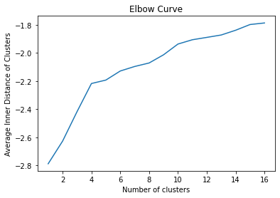

```python
elbow_curve(1,16,10000)
```

Analizando la curva de codo, 4 parece ser el número ideal de clusters, entonces vamos a segmentar los clientes en 4 grupos.

```python
#assigning every client to one centroid
#returning list of centroids
client_centr = k_means(4,10000)
```

Guardamos los miembros del cluster para cada centroide, para cada centroide entonces creamos una lista de los nits de los cliente que pertenecen a este cluster.

```python
#save members of cluster for every centroid
for client in list_of_clients:
  client.centroid.members.append(client)

#create list of clusters consisting of the nit of every client belonging to it
list_of_clusters = []
for centroid in client_centr:
  cluster = []
  for client in centroid.members:
    cluster.append(client.nit)
  list_of_clusters.append(cluster)
```

```python
#create a list of clusters constisting of the data of the clients belonging to it
clustered_data = []

for cluster in list_of_clusters:
  clustered_data.append(datos.loc[datos['nit'].isin(cluster)])
```

Visualizamos en dataframes los datos de cada cluster.

```python
#print head of every cluster
for i in range(len(clustered_data)):
  cluster = clustered_data[i]
  print("Cluster " + str(i+1))
  display(cluster.head())
  print("")
  print("")
  print("")
  print("")
```

```
Cluster 1
```

|  | nit | impo_cv | expo_vt | cxp | cxc | totalinventory | pagos_pj | pagos_pn | tiene_ventas_fisicas | tiene_ventas_electronicas | recaudos_pj | recaudos_pn | rotacion_inventarios | rotacion_cxc | rotacion_cxp | ciclo_negocio | ciclo_financiero | en_vm_total | en_tx_total | sal_vm_total | sal_tx_total | en_vm_total_t | en_tx_total_t | sal_vm_total_t | sal_tx_total_t | vm_segmentation | tx_segmentation |
| --- | --- | --- | --- | --- | --- | --- | --- | --- | --- | --- | --- | --- | --- | --- | --- | --- | --- | --- | --- | --- | --- | --- | --- | --- | --- | --- | --- |
| 3 | C7393816976826597531 | 2 | 2 | 1 | 1 | 1 | 0.615 | 0.385 | 1 | 0 | 0.0 | 0.0 | 5 | 2 | 3 | 5 | 5 | 1.601709e+08 | 36.650000 | 6.055844e+07 | 10.333333 | -0.224469 | -0.553427 | 0.085289 | -0.660195 | normal | normal |
| 12 | C-1460962288922693118 | 4 | 2 | 3 | 3 | 3 | 0.519 | 0.481 | 1 | 0 | 0.0 | 0.0 | 5 | 3 | 4 | 5 | 5 | 4.202319e+09 | 449.500000 | 1.965621e+09 | 474.500000 | 0.358327 | 0.448209 | 0.508552 | 0.712395 | normal | normal |
| 13 | C5450482602053655177 | 2 | 2 | 2 | 3 | 2 | 0.623 | 0.377 | 0 | 0 | 0.0 | 0.0 | 2 | 3 | 1 | 4 | 4 | 1.453773e+09 | 19.766667 | 6.810833e+08 | 6.666667 | 0.168981 | -0.793536 | 0.379640 | -0.803773 | normal | normal |
| 15 | C4476832459320426009 | 2 | 2 | 1 | 2 | 2 | 0.709 | 0.291 | 0 | 0 | 0.0 | 0.0 | 3 | 3 | 1 | 4 | 5 | 3.376623e+08 | 26.750000 | 2.381782e+08 | 117.583333 | -0.091432 | -0.676551 | 0.251848 | 0.202259 | normal | normal |
| 16 | C8497084211255542375 | 2 | 2 | 4 | 3 | 3 | 1.000 | 0.000 | 1 | 0 | 0.0 | 0.0 | 5 | 3 | 4 | 5 | 3 | 1.004163e+09 | 555.904762 | 6.557960e+05 | 1.000000 | 0.102979 | 0.533777 | -0.465145 | -1.297374 | normal | mayor_entrada |

```
Cluster 2
```

|  | nit | impo_cv | expo_vt | cxp | cxc | totalinventory | pagos_pj | pagos_pn | tiene_ventas_fisicas | tiene_ventas_electronicas | recaudos_pj | recaudos_pn | rotacion_inventarios | rotacion_cxc | rotacion_cxp | ciclo_negocio | ciclo_financiero | en_vm_total | en_tx_total | sal_vm_total | sal_tx_total | en_vm_total_t | en_tx_total_t | sal_vm_total_t | sal_tx_total_t | vm_segmentation | tx_segmentation |
| --- | --- | --- | --- | --- | --- | --- | --- | --- | --- | --- | --- | --- | --- | --- | --- | --- | --- | --- | --- | --- | --- | --- | --- | --- | --- | --- | --- |
| 0 | C4936394968152386565 | 1 | 1 | 6 | 6 | 6 | 0.000 | 0.000 | 0 | 0 | 0.0 | 0.0 | 6 | 2 | 2 | 5 | 6 | 0.000000e+00 | 0.000000 | 0.0 | 0.0 | -3.594388 | -2.017662 | -2.094195 | -1.551991 | normal | normal |
| 1 | C-8615176103348111575 | 1 | 1 | 2 | 6 | 2 | 1.000 | 0.000 | 0 | 0 | 0.0 | 0.0 | 1 | 3 | 1 | 3 | 4 | 0.000000e+00 | 0.000000 | 0.0 | 0.0 | -3.594388 | -2.017662 | -2.094195 | -1.551991 | normal | normal |
| 7 | C-7726318191327882846 | 2 | 2 | 2 | 1 | 6 | 0.000 | 0.000 | 0 | 0 | 0.0 | 0.0 | 6 | 1 | 1 | 6 | 6 | 0.000000e+00 | 0.000000 | 0.0 | 0.0 | -3.594388 | -2.017662 | -2.094195 | -1.551991 | normal | normal |
| 8 | C6428084652960048574 | 2 | 2 | 3 | 1 | 4 | 1.000 | 0.000 | 1 | 0 | 0.0 | 0.0 | 6 | 1 | 4 | 6 | 5 | 5.760230e+08 | 888.000000 | 0.0 | 0.0 | 0.003842 | 0.722521 | -2.094195 | -1.551991 | normal | mayor_entrada |
| 21 | C2259359539244597893 | 3 | 2 | 2 | 3 | 2 | 0.962 | 0.038 | 0 | 0 | 0.0 | 0.0 | 3 | 3 | 2 | 4 | 4 | 1.167327e+09 | 78.833333 | 0.0 | 0.0 | 0.129836 | -0.250111 | -2.094195 | -1.551991 | normal | normal |

```
Cluster 3
```

|  | nit | impo_cv | expo_vt | cxp | cxc | totalinventory | pagos_pj | pagos_pn | tiene_ventas_fisicas | tiene_ventas_electronicas | recaudos_pj | recaudos_pn | rotacion_inventarios | rotacion_cxc | rotacion_cxp | ciclo_negocio | ciclo_financiero | en_vm_total | en_tx_total | sal_vm_total | sal_tx_total | en_vm_total_t | en_tx_total_t | sal_vm_total_t | sal_tx_total_t | vm_segmentation | tx_segmentation |
| --- | --- | --- | --- | --- | --- | --- | --- | --- | --- | --- | --- | --- | --- | --- | --- | --- | --- | --- | --- | --- | --- | --- | --- | --- | --- | --- | --- |
| 9 | C-6937758062773673148 | 2 | 2 | 3 | 6 | 3 | 0.000 | 1.000 | 0 | 0 | 0.00 | 0.00 | 1 | 3 | 1 | 4 | 4 | 1.352607e+09 | 28.333333 | 9.685609e+08 | 1321.833333 | 0.156115 | -0.654158 | 0.422469 | 1.088239 | normal | mayor_salida |
| 11 | C7157587019886589653 | 2 | 2 | 6 | 4 | 4 | 0.062 | 0.938 | 1 | 0 | 0.00 | 0.00 | 1 | 1 | 1 | 2 | 2 | 9.191665e+09 | 3035.319445 | 3.383677e+09 | 1664.166667 | 0.497938 | 1.218211 | 0.574615 | 1.172781 | normal | normal |
| 14 | C-1722188528960302335 | 2 | 2 | 2 | 4 | 2 | 0.386 | 0.614 | 0 | 0 | 0.00 | 0.00 | 2 | 3 | 1 | 4 | 5 | 5.844106e+09 | 1130.788889 | 3.810139e+09 | 394.216667 | 0.417156 | 0.819963 | 0.589053 | 0.644463 | normal | normal |
| 17 | C3146061519075383431 | 2 | 2 | 4 | 4 | 2 | 0.465 | 0.535 | 1 | 0 | 0.00 | 0.00 | 2 | 4 | 4 | 5 | 3 | 8.188249e+08 | 119.283333 | 5.123550e+08 | 105.166667 | 0.066582 | -0.084690 | 0.345016 | 0.161630 | normal | normal |
| 23 | C5664836048857676643 | 2 | 2 | 6 | 6 | 3 | 0.767 | 0.233 | 1 | 0 | 0.05 | 0.95 | 1 | 2 | 2 | 2 | 2 | 8.041662e+10 | 81247.950000 | 0.000000e+00 | 0.000000 | 0.884832 | 2.544647 | -2.094195 | -1.551991 | mayor_entrada | mayor_entrada |

```
Cluster 4
```

|  | nit | impo_cv | expo_vt | cxp | cxc | totalinventory | pagos_pj | pagos_pn | tiene_ventas_fisicas | tiene_ventas_electronicas | recaudos_pj | recaudos_pn | rotacion_inventarios | rotacion_cxc | rotacion_cxp | ciclo_negocio | ciclo_financiero | en_vm_total | en_tx_total | sal_vm_total | sal_tx_total | en_vm_total_t | en_tx_total_t | sal_vm_total_t | sal_tx_total_t | vm_segmentation | tx_segmentation |
| --- | --- | --- | --- | --- | --- | --- | --- | --- | --- | --- | --- | --- | --- | --- | --- | --- | --- | --- | --- | --- | --- | --- | --- | --- | --- | --- | --- |
| 2 | C2364605246729357060 | 1 | 1 | 3 | 1 | 2 | 0.456 | 0.544 | 1 | 0 | 0.0 | 0.0 | 2 | 1 | 2 | 2 | 1 | 2.874188e+09 | 293.695455 | 2.678976e+09 | 615.628788 | 0.290566 | 0.276933 | 0.546211 | 0.807866 | normal | normal |
| 4 | C872645851723947566 | 1 | 1 | 2 | 2 | 2 | 1.000 | 0.000 | 1 | 0 | 0.0 | 0.0 | 2 | 2 | 1 | 3 | 3 | 7.237497e+08 | 371.783333 | 6.220807e+08 | 53.416667 | 0.044566 | 0.371791 | 0.368618 | -0.083875 | normal | mayor_entrada |
| 5 | C-3870380727390720970 | 1 | 1 | 1 | 3 | 1 | 0.590 | 0.410 | 0 | 0 | 0.0 | 0.0 | 1 | 4 | 1 | 5 | 5 | 8.237720e+07 | 19.500000 | 1.960611e+09 | 90.000000 | -0.343080 | -0.798752 | 0.508241 | 0.105005 | mayor_salida | normal |
| 6 | C1404615104540746817 | 1 | 1 | 1 | 4 | 1 | 1.000 | 0.000 | 0 | 0 | 0.0 | 0.0 | 2 | 4 | 1 | 6 | 6 | 1.756789e+09 | 2.333333 | 6.045320e+08 | 3.833333 | 0.202753 | -1.531792 | 0.365138 | -0.973242 | normal | normal |
| 10 | C-6938443690430410016 | 1 | 1 | 1 | 2 | 2 | 0.741 | 0.259 | 1 | 0 | 0.0 | 0.0 | 2 | 2 | 1 | 3 | 4 | 2.887042e+09 | 426.295455 | 8.055108e+08 | 34.000000 | 0.291362 | 0.426868 | 0.400048 | -0.245988 | normal | mayor_entrada |

Observando un poco la división de estso clusters en sus primeros 5 representantes...

Para el cluster 1 en las variables *Exportaciones e Importaciones* parece haber cierta relación de valores pequeños que podrían estar entre 1 y 4 más o menos, así mismo *Ciclo de negocio* los valores dan la impresión de estar entre 4 y 5, con una media que se podría intuir como común en 4.5 para elementos de este cluster y por último otra variable interesante de este grupo es la *Rotación de cuentas por cobrar (rotacion_cxc)* sus valores parecen entre ellos, estár cercanos a 3.

Siguiendo con el cluster 2, hay 2 varibles relacionadas que indicarían algo y es que las *Salidas de Valor medio y de Cantidad de Transacciones* sus valores son 0, pero aparece otra variable que se podría relacionar a las anteriormente descritas y es *Pagos a personas naturales (Pagos_pn)* que también están cercanos a 0, por lo que se creería que son clientes que sólo hacen movimientos de entrada, que si se piensa desde el punto de vista de un banco por ejemplo, sería un cliente que tiene una gran tendencia a hacer ahorros y a gastar pocos recursos de estos.

Cluster 3, en este grupo da la impresión de haber valores muy comunes en *Importaciones y Exportaciones*, pero mirando otras columnas hay algo que nos podría decir un poco más y son los valores de las variables de comportamientos *Entradas y Salidas* en las que hay valores muy altos en ambos, por lo que se pensaría que corresponde a un grupo de clientes que mueven altas cantidades de dinero tanto de salida como entrada, ya se procedería a ver a que tipo de organización pertenecerían y determinar su capacidad económica.

Finalmente, en el cluster 4, parece haber cierta relación entre los clientes en *Exportaciones e Iportaciones*, son clientes que mueven altas sumas de dinero y que tienen cierta similitud en *Total inventory* con valores bajos más o menos entre 1 y 2.

Otro punto que puede ser curioso es que hay 3 variables *tiene_ventas_electronicas, recuados_oj, recaudos_pn* que en estos primeros 5 clientes de cada cluster muestran en todas (salvo en el cluster 3, recaudos del cliente 23) valores de 0, entonces a continuación con un análisis un poquito mejor se podría observar que tan diciente podría ser para el modelo estas variables, ya que muchos clientes no marcan valores en estos ítems.

Hacemos un análisis estadístico de cada cluster.

```python
#analyze every cluster using "describe"
for i in range(len(clustered_data)):
  cluster = clustered_data[i]
  print("Cluster " + str(i+1))
  display(cluster.describe())
  print("")
  print("")
  print("")
  print("")
```

```
Cluster 1
```

|  | impo_cv | expo_vt | cxp | cxc | totalinventory | pagos_pj | pagos_pn | tiene_ventas_fisicas | tiene_ventas_electronicas | recaudos_pj | recaudos_pn | rotacion_inventarios | rotacion_cxc | rotacion_cxp | ciclo_negocio | ciclo_financiero | en_vm_total | en_tx_total | sal_vm_total | sal_tx_total | en_vm_total_t | en_tx_total_t | sal_vm_total_t | sal_tx_total_t |
| --- | --- | --- | --- | --- | --- | --- | --- | --- | --- | --- | --- | --- | --- | --- | --- | --- | --- | --- | --- | --- | --- | --- | --- | --- |
| count | 574.000000 | 574.000000 | 574.000000 | 574.000000 | 574.000000 | 574.000000 | 574.000000 | 574.000000 | 574.000000 | 574.000000 | 574.000000 | 574.000000 | 574.000000 | 574.000000 | 574.000000 | 574.000000 | 5.740000e+02 | 574.000000 | 5.740000e+02 | 574.000000 | 574.000000 | 574.000000 | 574.000000 | 574.000000 |
| mean | 2.545296 | 1.942509 | 2.402439 | 2.775261 | 3.541812 | 0.664784 | 0.324782 | 0.473868 | 0.034843 | 0.016911 | 0.052775 | 4.879791 | 2.590592 | 2.470383 | 5.219512 | 4.904181 | 2.528647e+09 | 517.793571 | 1.251243e+09 | 194.705845 | 0.158305 | -0.064056 | 0.317889 | -0.059024 |
| std | 1.166970 | 0.598285 | 1.365261 | 1.361403 | 1.536352 | 0.237648 | 0.230028 | 0.499752 | 0.183542 | 0.108321 | 0.212501 | 1.418345 | 1.123126 | 1.195539 | 1.009848 | 1.516477 | 3.421109e+09 | 1519.107399 | 2.173972e+09 | 309.482531 | 0.259367 | 0.683144 | 0.309960 | 0.685129 |
| min | 1.000000 | 1.000000 | 1.000000 | 1.000000 | 1.000000 | 0.000000 | 0.000000 | 0.000000 | 0.000000 | 0.000000 | 0.000000 | 1.000000 | 1.000000 | 1.000000 | 1.000000 | 1.000000 | 0.000000e+00 | 0.000000 | 0.000000e+00 | 0.000000 | -3.594388 | -2.017662 | -2.094195 | -1.551991 |
| 25% | 2.000000 | 2.000000 | 1.000000 | 2.000000 | 2.000000 | 0.486000 | 0.130500 | 0.000000 | 0.000000 | 0.000000 | 0.000000 | 4.000000 | 2.000000 | 1.000000 | 5.000000 | 4.000000 | 7.652982e+08 | 33.145833 | 2.346967e+08 | 12.604167 | 0.054523 | -0.592856 | 0.250054 | -0.593110 |
| 50% | 2.000000 | 2.000000 | 2.000000 | 3.000000 | 3.000000 | 0.670500 | 0.324500 | 0.000000 | 0.000000 | 0.000000 | 0.000000 | 6.000000 | 3.000000 | 2.000000 | 6.000000 | 6.000000 | 1.566745e+09 | 150.086310 | 6.667337e+08 | 85.750000 | 0.182330 | 0.007320 | 0.377050 | 0.087433 |
| 75% | 4.000000 | 2.000000 | 3.000000 | 3.000000 | 5.000000 | 0.863000 | 0.509750 | 1.000000 | 0.000000 | 0.000000 | 0.000000 | 6.000000 | 4.000000 | 4.000000 | 6.000000 | 6.000000 | 2.992988e+09 | 415.158865 | 1.358738e+09 | 274.750000 | 0.297791 | 0.416201 | 0.463640 | 0.512243 |
| max | 5.000000 | 3.000000 | 6.000000 | 6.000000 | 6.000000 | 1.000000 | 0.913000 | 1.000000 | 1.000000 | 1.000000 | 1.000000 | 6.000000 | 4.000000 | 4.000000 | 6.000000 | 6.000000 | 3.357757e+10 | 19807.849997 | 2.626277e+10 | 3482.250000 | 0.729041 | 1.975073 | 0.823856 | 1.443889 |

```
Cluster 2
```

|  | impo_cv | expo_vt | cxp | cxc | totalinventory | pagos_pj | pagos_pn | tiene_ventas_fisicas | tiene_ventas_electronicas | recaudos_pj | recaudos_pn | rotacion_inventarios | rotacion_cxc | rotacion_cxp | ciclo_negocio | ciclo_financiero | en_vm_total | en_tx_total | sal_vm_total | sal_tx_total | en_vm_total_t | en_tx_total_t | sal_vm_total_t | sal_tx_total_t |
| --- | --- | --- | --- | --- | --- | --- | --- | --- | --- | --- | --- | --- | --- | --- | --- | --- | --- | --- | --- | --- | --- | --- | --- | --- |
| count | 382.000000 | 382.000000 | 382.000000 | 382.000000 | 382.000000 | 382.000000 | 382.000000 | 382.000000 | 382.000000 | 382.000000 | 382.000000 | 382.000000 | 382.000000 | 382.000000 | 382.000000 | 382.000000 | 3.820000e+02 | 382.000000 | 3.820000e+02 | 382.000000 | 382.000000 | 382.000000 | 382.000000 | 382.000000 |
| mean | 1.874346 | 1.599476 | 2.887435 | 3.465969 | 3.201571 | 0.686076 | 0.214450 | 0.293194 | 0.002618 | 0.002618 | 0.005236 | 2.876963 | 2.473822 | 2.251309 | 4.128272 | 3.874346 | 1.569456e+09 | 280.877726 | 2.378661e+05 | 0.035079 | -1.380625 | -1.115697 | -2.070338 | -1.546618 |
| std | 1.057368 | 0.618439 | 1.738977 | 1.912150 | 1.880609 | 0.321329 | 0.237095 | 0.455824 | 0.051164 | 0.034218 | 0.061441 | 1.935453 | 1.200654 | 1.174839 | 1.602749 | 1.809836 | 5.616090e+09 | 1806.318025 | 3.782285e+06 | 0.429215 | 1.747199 | 0.964169 | 0.209365 | 0.052236 |
| min | 1.000000 | 1.000000 | 1.000000 | 1.000000 | 1.000000 | 0.000000 | 0.000000 | 0.000000 | 0.000000 | 0.000000 | 0.000000 | 1.000000 | 1.000000 | 1.000000 | 1.000000 | 1.000000 | 0.000000e+00 | 0.000000 | 0.000000e+00 | 0.000000 | -3.594388 | -2.017662 | -2.094195 | -1.551991 |
| 25% | 1.000000 | 1.000000 | 2.000000 | 2.000000 | 2.000000 | 0.500000 | 0.000000 | 0.000000 | 0.000000 | 0.000000 | 0.000000 | 1.000000 | 1.000000 | 1.000000 | 3.000000 | 2.000000 | 0.000000e+00 | 0.000000 | 0.000000e+00 | 0.000000 | -3.594388 | -2.017662 | -2.094195 | -1.551991 |
| 50% | 2.000000 | 2.000000 | 2.000000 | 3.000000 | 3.000000 | 0.777000 | 0.143000 | 0.000000 | 0.000000 | 0.000000 | 0.000000 | 2.000000 | 2.000000 | 2.000000 | 4.000000 | 4.000000 | 8.990703e+07 | 3.266667 | 0.000000e+00 | 0.000000 | -0.327480 | -1.432220 | -2.094195 | -1.551991 |
| 75% | 2.000000 | 2.000000 | 4.000000 | 6.000000 | 5.000000 | 1.000000 | 0.370500 | 1.000000 | 0.000000 | 0.000000 | 0.000000 | 4.750000 | 4.000000 | 3.000000 | 6.000000 | 6.000000 | 9.275921e+08 | 53.187500 | 0.000000e+00 | 0.000000 | 0.088828 | -0.407230 | -2.094195 | -1.551991 |
| max | 5.000000 | 3.000000 | 6.000000 | 6.000000 | 6.000000 | 1.000000 | 0.930000 | 1.000000 | 1.000000 | 0.500000 | 0.942000 | 6.000000 | 4.000000 | 4.000000 | 6.000000 | 6.000000 | 6.240732e+10 | 25235.535718 | 7.210026e+07 | 7.900000 | 0.839606 | 2.072800 | 0.106507 | -0.748978 |

```
Cluster 3
```

|  | impo_cv | expo_vt | cxp | cxc | totalinventory | pagos_pj | pagos_pn | tiene_ventas_fisicas | tiene_ventas_electronicas | recaudos_pj | recaudos_pn | rotacion_inventarios | rotacion_cxc | rotacion_cxp | ciclo_negocio | ciclo_financiero | en_vm_total | en_tx_total | sal_vm_total | sal_tx_total | en_vm_total_t | en_tx_total_t | sal_vm_total_t | sal_tx_total_t |
| --- | --- | --- | --- | --- | --- | --- | --- | --- | --- | --- | --- | --- | --- | --- | --- | --- | --- | --- | --- | --- | --- | --- | --- | --- |
| count | 727.000000 | 727.000000 | 727.000000 | 727.000000 | 727.000000 | 727.000000 | 727.000000 | 727.000000 | 727.000000 | 727.000000 | 727.000000 | 727.000000 | 727.000000 | 727.000000 | 727.000000 | 727.000000 | 7.270000e+02 | 7.270000e+02 | 7.270000e+02 | 727.000000 | 727.000000 | 727.000000 | 727.000000 | 727.000000 |
| mean | 2.331499 | 1.984869 | 4.136176 | 5.116919 | 4.316369 | 0.400741 | 0.599263 | 0.588721 | 0.082531 | 0.055098 | 0.115468 | 2.640990 | 2.609354 | 2.178817 | 4.055021 | 3.825309 | 2.914285e+10 | 1.389452e+04 | 1.981099e+10 | 1886.302094 | 0.495662 | 0.668506 | 0.576293 | 0.716015 |
| std | 0.853698 | 0.455807 | 1.733449 | 1.302182 | 1.753876 | 0.231287 | 0.231284 | 0.492404 | 0.275361 | 0.187434 | 0.292015 | 1.531712 | 1.105369 | 1.078690 | 1.323552 | 1.585408 | 1.153667e+11 | 1.382012e+05 | 8.802925e+10 | 4565.370757 | 0.238683 | 0.823769 | 0.338027 | 0.724322 |
| min | 1.000000 | 1.000000 | 1.000000 | 1.000000 | 1.000000 | 0.000000 | 0.000000 | 0.000000 | 0.000000 | 0.000000 | 0.000000 | 1.000000 | 1.000000 | 1.000000 | 1.000000 | 1.000000 | 9.056119e+07 | 2.600000e+00 | 0.000000e+00 | 0.000000 | -0.326184 | -1.500734 | -2.094195 | -1.551991 |
| 25% | 2.000000 | 2.000000 | 3.000000 | 4.000000 | 3.000000 | 0.227000 | 0.468500 | 0.000000 | 0.000000 | 0.000000 | 0.000000 | 1.000000 | 2.000000 | 1.000000 | 3.000000 | 3.000000 | 3.879695e+09 | 2.051490e+02 | 1.669863e+09 | 195.715909 | 0.344075 | 0.132694 | 0.488713 | 0.388183 |
| 50% | 2.000000 | 2.000000 | 4.000000 | 6.000000 | 5.000000 | 0.383000 | 0.617000 | 1.000000 | 0.000000 | 0.000000 | 0.000000 | 2.000000 | 3.000000 | 2.000000 | 4.000000 | 4.000000 | 8.303737e+09 | 6.912561e+02 | 4.312020e+09 | 662.166667 | 0.479817 | 0.621575 | 0.604103 | 0.834593 |
| 75% | 3.000000 | 2.000000 | 6.000000 | 6.000000 | 6.000000 | 0.531500 | 0.773000 | 1.000000 | 0.000000 | 0.000000 | 0.000000 | 3.000000 | 4.000000 | 3.000000 | 5.000000 | 5.000000 | 1.888502e+10 | 2.465847e+03 | 1.143962e+10 | 1664.291667 | 0.626385 | 1.134388 | 0.722764 | 1.172809 |
| max | 5.000000 | 3.000000 | 6.000000 | 6.000000 | 6.000000 | 1.000000 | 1.000000 | 1.000000 | 1.000000 | 1.000000 | 1.000000 | 6.000000 | 4.000000 | 4.000000 | 6.000000 | 6.000000 | 2.360979e+12 | 3.521799e+06 | 1.663148e+12 | 73136.166663 | 1.487689 | 4.065734 | 1.328411 | 2.562192 |

```
Cluster 4
```

|  | impo_cv | expo_vt | cxp | cxc | totalinventory | pagos_pj | pagos_pn | tiene_ventas_fisicas | tiene_ventas_electronicas | recaudos_pj | recaudos_pn | rotacion_inventarios | rotacion_cxc | rotacion_cxp | ciclo_negocio | ciclo_financiero | en_vm_total | en_tx_total | sal_vm_total | sal_tx_total | en_vm_total_t | en_tx_total_t | sal_vm_total_t | sal_tx_total_t |
| --- | --- | --- | --- | --- | --- | --- | --- | --- | --- | --- | --- | --- | --- | --- | --- | --- | --- | --- | --- | --- | --- | --- | --- | --- |
| count | 550.000000 | 550.000000 | 550.000000 | 550.000000 | 550.000000 | 550.000000 | 550.000000 | 550.000000 | 550.000000 | 550.000000 | 550.000000 | 550.000000 | 550.000000 | 550.000000 | 550.000000 | 550.000000 | 5.500000e+02 | 550.000000 | 5.500000e+02 | 550.000000 | 550.000000 | 550.000000 | 550.000000 | 550.000000 |
| mean | 1.221818 | 1.194545 | 1.901818 | 2.187273 | 2.016364 | 0.489345 | 0.508847 | 0.454545 | 0.056364 | 0.011456 | 0.037635 | 1.974545 | 1.918182 | 1.852727 | 3.083636 | 3.036364 | 3.102230e+09 | 1059.304371 | 2.229322e+09 | 441.653540 | 0.138518 | -0.041891 | 0.344429 | 0.189355 |
| std | 0.495771 | 0.396211 | 1.003362 | 1.151313 | 1.265237 | 0.262509 | 0.262575 | 0.498383 | 0.230833 | 0.078179 | 0.176211 | 1.411405 | 1.062113 | 1.049825 | 1.518647 | 1.597626 | 1.103158e+10 | 5090.095576 | 1.005171e+10 | 1060.929207 | 0.323137 | 0.756297 | 0.370177 | 0.705059 |
| min | 1.000000 | 1.000000 | 1.000000 | 1.000000 | 1.000000 | 0.000000 | 0.000000 | 0.000000 | 0.000000 | 0.000000 | 0.000000 | 1.000000 | 1.000000 | 1.000000 | 1.000000 | 1.000000 | 0.000000e+00 | 0.000000 | 0.000000e+00 | 0.000000 | -3.594388 | -2.017662 | -2.094195 | -1.551991 |
| 25% | 1.000000 | 1.000000 | 1.000000 | 1.000000 | 1.000000 | 0.294250 | 0.315750 | 0.000000 | 0.000000 | 0.000000 | 0.000000 | 1.000000 | 1.000000 | 1.000000 | 2.000000 | 2.000000 | 5.799315e+08 | 28.534722 | 2.676152e+08 | 39.687500 | 0.005046 | -0.651407 | 0.266022 | -0.190681 |
| 50% | 1.000000 | 1.000000 | 2.000000 | 2.000000 | 2.000000 | 0.467500 | 0.532000 | 0.000000 | 0.000000 | 0.000000 | 0.000000 | 1.000000 | 2.000000 | 1.000000 | 3.000000 | 3.000000 | 1.380043e+09 | 121.560227 | 7.512887e+08 | 157.079545 | 0.159695 | -0.077127 | 0.391572 | 0.307861 |
| 75% | 1.000000 | 1.000000 | 2.000000 | 3.000000 | 2.000000 | 0.681500 | 0.705000 | 1.000000 | 0.000000 | 0.000000 | 0.000000 | 2.000000 | 3.000000 | 2.000000 | 4.000000 | 4.000000 | 2.921088e+09 | 470.729167 | 2.067237e+09 | 460.312500 | 0.293451 | 0.466791 | 0.514682 | 0.701267 |
| max | 4.000000 | 2.000000 | 6.000000 | 6.000000 | 6.000000 | 1.000000 | 0.996000 | 1.000000 | 1.000000 | 1.000000 | 1.000000 | 6.000000 | 4.000000 | 4.000000 | 6.000000 | 6.000000 | 2.471119e+11 | 87129.000000 | 2.269538e+11 | 14565.166667 | 1.085086 | 2.572849 | 1.086160 | 1.969448 |

## Referencias

Aprendemachinelearning. (12 de 3 de 2018). Obtenido de https://www.aprendemachinelearning.com/k-means-en-python-paso-a-paso/

.

Rodrigo, J. A. (9 de 2017). Cienciadedatos. Obtenido de https://www.cienciadedatos.net/documentos/37_clustering_y_heatmaps

.

StackOverflow. (2010). Obtenido de https://stackoverflow.com/questions/7368739/numpy-and-16-bit-pgm